# Chapter 4 - Overffiting and Its Avoidence

### Criterion - $C_p$ , AIC, BIC

## Criterion - $C_p$, AIC, BIC

In order to select the best model with respect to test error, we need to estimate this test error. We can indirectly estimate test error by making an adjustment to the training error to account for the bias due to overfitting. $C_p$, AIC and BIC can be seen as estimators of test MSE. For a fitted least squares model containing d predictors, the $C_p$ estimate of test MSE is computed using the equation
$$C_p = \frac{1}{n}(RSS(d) + 2d\hat{\sigma^2}),$$
where $\hat{\sigma^2}$ is the estimated variance for $\epsilon$ with the full model. If the errors are Gaussian, AIC is given by
$$AIC = \log(\hat{\sigma}^2_d) + 2d/n$$
BIC is derived from a Bayesian point of view, but ends up looking similar to $C_p$ (and AIC) as well. For the least squares model with $d$ predictors, the BIC is given by
$$BIC =\log(\hat{\sigma}^2_d) + \log{(n)}d/n.$$

```r
library(leaps)
library(ISLR) # dataset: Hitters

Hitters0 = na.omit(Hitters)
hitSubreg = regsubsets(Salary ~ ., data = Hitters0, nvmax = 19, method = "forward")
hitSubreg_sum = summary(hitSubreg)
print(hitSubreg_sum)
```

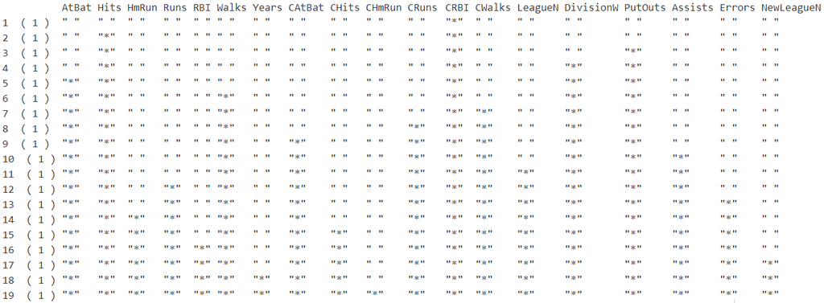

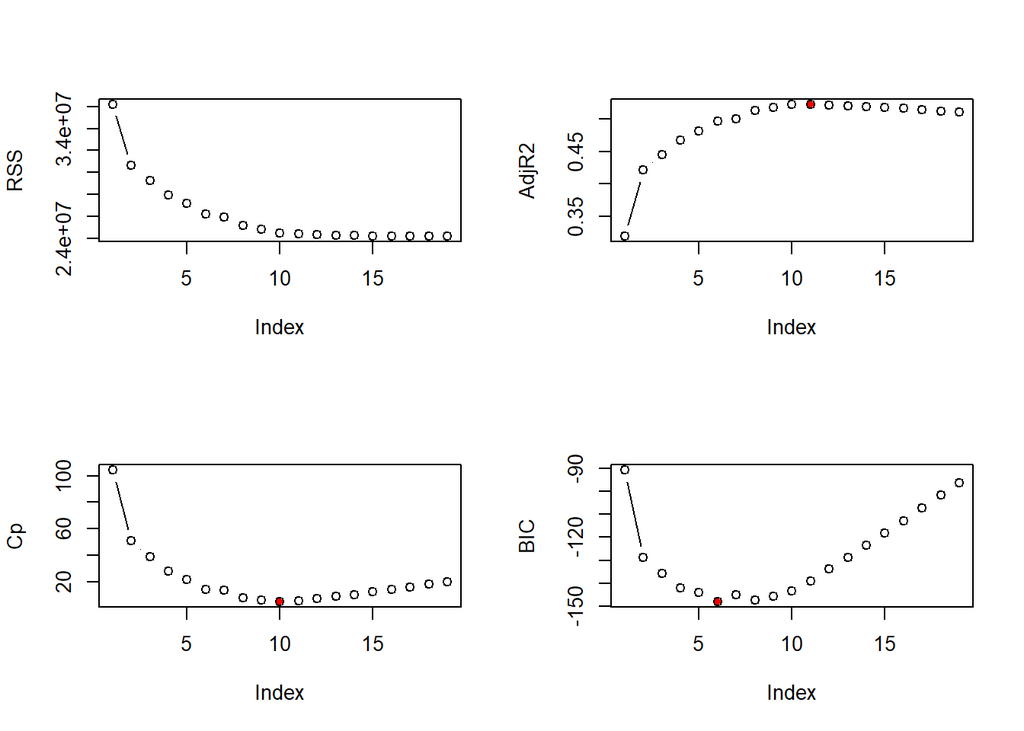

```r
par(mfrow = c(2, 2))

plot(hitSubreg_sum$rss, type = "b", ylab = "RSS")

plot(hitSubreg_sum$adjr2, type = "b", ylab = "AdjR2")
points(x = which.max(hitSubreg_sum$adjr2), y = max(hitSubreg_sum$adjr2), pch = 20, col = "red")

plot(hitSubreg_sum$cp, type = "b", ylab = "Cp")
points(x = which.min(hitSubreg_sum$cp), y = min(hitSubreg_sum$cp), pch = 20, col = "red")

plot(hitSubreg_sum$bic, type = "b", ylab = "BIC")
points(x = which.min(hitSubreg_sum$bic), y = min(hitSubreg_sum$bic), pch = 20, col = "red")
```

## Cross Validation

Let us recall $k$-fold cross validation first. This approach involves randomly $k$-fold CV dividing the set of observations into $k$ groups, or folds, of approximately equal size. The first fold is treated as a validation set, and the method is fitting on the remaining $k - 1$ folds. The mean squared error, $MSE_1$, is then computed on the observations in the held-out fold. This process results in $k$ estimates of the test error, $MSE_1,MSE_2, \dots, MSE_k$. The $k$-fold CV estimate is computed by averaging these values,
$$CV_{(k)} = \frac{1}{k}\sum^k_{i=1}MSE_i.$$
Cross-validation can also be a very useful approach in the classification setting when $Y$ is qualitative. The $k$-fold CV estimate is computed by averaging error rate,
$$CV_{(k)} = \frac{1}{k}\sum^k_{i=1}Err_i,$$
where $Err_i$ is then computed on the observations in the held-out fold.

The `cv.glm()` function can also be used to implement $k$-fold CV. Below we use $k$ = 10, a common choice for $k$, on the Auto data set. We once again initialize a vector in which we will store the CV errors corresponding to the polynomial fits of orders one to ten.

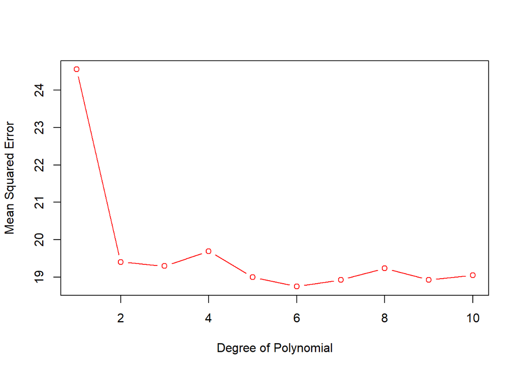

```r
library(ISLR) # dataset: Auto
Auto = na.omit(Auto)

cvError = rep (0, 10)
library(boot)
for (i in 1:10) {
  glmFit = glm(mpg ~ poly(horsepower , i), data = Auto)
  cvError[i] = cv.glm(Auto, glmFit, K = 10)$delta[1]
}
plot(1:10, cvError, type = "b", xlab = "Degree of Polynomial", ylab = "Mean Squared Error", col = 2)
```

## Ridge Regression

**Ridge** regression is very similar to least squares, except that the coefficients are estimated by minimizing a slightly different quantity. In particular, the **ridge** regression coefficient estimates $\hat{\beta}^R$ are the values that minimize
$$\sum_{i=1}^n\Big(y_i - \beta_0 - \sum_{j=1}^p\beta_jx_{ij} \Big)^2 + \lambda\sum^p_{j=1}\beta^2_j = RSS + \lambda\sum^p_{j=1}\beta^2_j,$$
where $\lambda > 0$ is a tuning parameter, to be determined separately.

Ridge regression’s advantage over least squares is rooted in the *bias-variance trade-off*. In general, in situations where the relationship between the response and the predictors is close to linear, the least squares estimates will have low bias but may have high variance. This means that a small change in the training data can cause a large change in the least squares coefficient estimates. Ridge regression works best in situations where the least squares estimates have high variance.

We will use the `glmnet` package in order to perform **ridge** regression and the **lasso**. The main function in this package is `glmnet()`, which can be used `glmnet()` to fit **ridge** regression models, **lasso** models, and more. In particular, we must pass in an $x$ matrix as well as a $y$ vector, and we do not use the $y \sim x$ syntax. Before proceeding ensure that the missing values have been removed from the data.

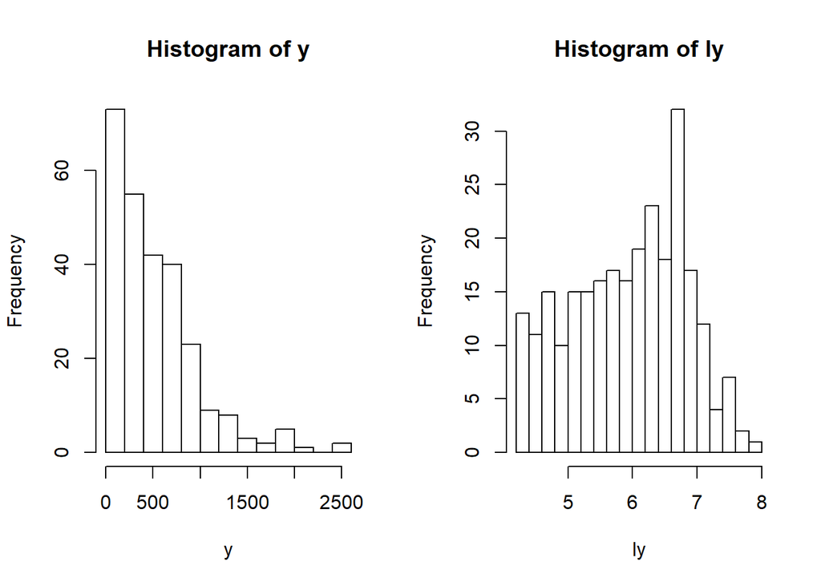

```r
library(glmnet) # Elastic Net
library(ISLR)
hit = na.omit(Hitters)
n = nrow(hit) # sample size

x = model.matrix(Salary ~ ., data = hit)
x = x[,-1]
x = scale(x)  # standardize

y = hit$Salary
par(mfrow = c(1, 2))
hist(y, nclass = 15)
ly = log(y)
hist(ly, nclass = 15)
```

We now split the samples into a training set and a test set in order to estimate the test error of **ridge** regression.

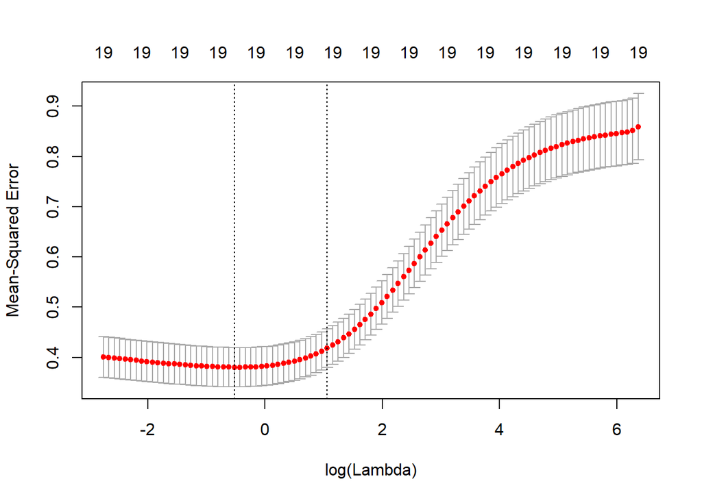

```r
set.seed(1234)
train = sample(1:n, size = n/2, replace = F)

ridge_cv = cv.glmnet(x[train,], ly[train], family = "gaussian", alpha = 0, nfolds = 10)
plot(ridge_cv)
```

```r
ridge_lambda = ridge_cv$lambda.min # lambda.1se
ridge_fit = glmnet(x[train,], ly[train], family = "gaussian", lambda = ridge_lambda, alpha = 0)
coef(ridge_fit)
ridge_pred = predict(ridge_fit, newx = x[-train, ])
```

```
## 20 x 1 sparse Matrix of class "dgCMatrix"
##                        s0
## (Intercept)  5.8763502647
## AtBat        0.0671871666
## Hits         0.1281902437
## HmRun        0.0218299627
## Runs         0.0894592510
## RBI          0.0571056007
## Walks        0.0741148777
## Years        0.1162139579
## CAtBat       0.0744202716
## CHits        0.0823171714
## CHmRun       0.0283272305
## CRuns        0.0686509469
## CRBI         0.0662316792
## CWalks       0.0246081469
## LeagueN      0.0001014357
## DivisionW   -0.0194012621
## PutOuts      0.0508215217
## Assists     -0.0031254597
## Errors      -0.0354335429
## NewLeagueN   0.0220360392
```

For the least squares coefficient estimation, which correspond to **ridge** regression with λ = 0, the variance is high but there is no bias. But as $\lambda$ increases, the shrinkage of the **ridge** coefficient estimates leads to a substantial reduction in the variance of the predictions, at the expense of a slight increase in bias. Hence, the results of test MSE illustrate that the **ridge** regression improve over least square since the **ridge** regression has advantage in the bias-variance trade-off.

## LASSO

The **ridge** regression will always generate a model involving all predictors. Increasing the value of $\lambda$ will tend to reduce the magnitudes of the coefficients, but will not result in exclusion of any of the variables. The **lasso** is a relatively recent alternative to **ridge** regression that overcomes this disadvantage. The **lasso** coefficients, $\hat{\beta}^L_\lambda$, minimize the quantity
$$\sum_{i=1}^n\Big(y_i - \beta_0 - \sum_{j=1}^p\beta_jx_{ij} \Big)^2 + \lambda\sum^p_{j=1}|\beta_j| = RSS + \lambda\sum^p_{j=1}|\beta_j|.$$

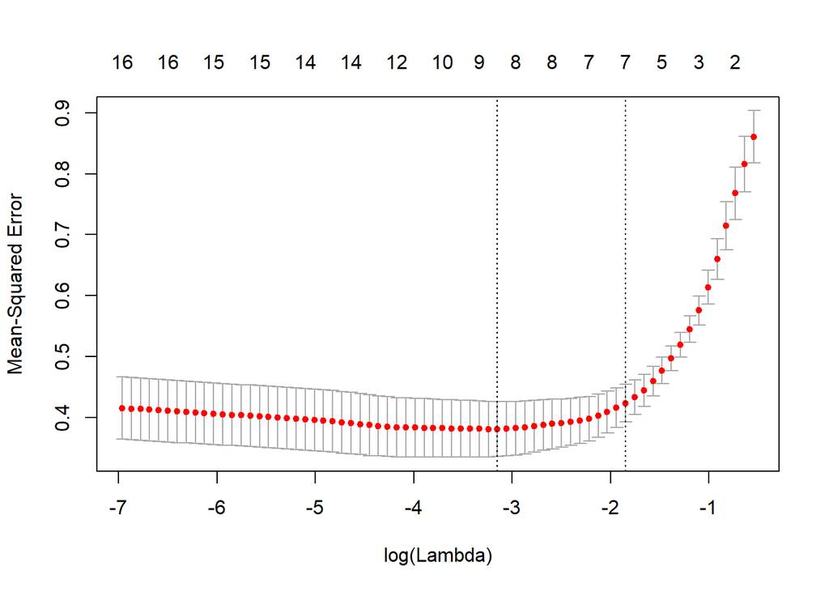

```r
lasso_cv = cv.glmnet(x[train, ], ly[train], family = "gaussian", alpha = 1, nfolds = 10)
plot(lasso_cv)
```

**One-Standard-Error Rule**: Select the smallest model for which the estimated test error is within one standard error of the lowest point on the curve.Try to find the simplest model which has almost the same accuracy as the MSE-minimized model.

```r
lasso_lambda = lasso_cv$lambda.1se #lambda.min
lasso_fit = glmnet(x[train,], ly[train], family = "gaussian", lambda = lasso_lambda, alpha = 1)
coef(lasso_fit)
lasso_pred = predict(lasso_fit, newx = x[-train, ])
```

```
## 20 x 1 sparse Matrix of class "dgCMatrix"
##                     s0
## (Intercept) 5.87604251
## AtBat       .
## Hits        0.27070290
## HmRun       .
## Runs        0.01151989
## RBI         .
## Walks       0.05707253
## Years       0.14990614
## CAtBat      .
## CHits       0.05833848
## CHmRun      .
## CRuns       0.06821693
## CRBI        0.11022949
## CWalks      .
## LeagueN     .
## DivisionW   .
## PutOuts     .
## Assists     .
## Errors      .
## NewLeagueN  .
```

```r
dat = data.frame(ly, x)
LS = lm(ly ~ ., data = dat, subset = train)
LS_pred = predict(LS, newdata = dat[-train,])

mean((exp(LS_pred) - y[-train]) ^ 2)
mean((exp(ridge_pred) - y[-train]) ^ 2)
mean((exp(lasso_pred) - y[-train]) ^ 2)
```

```
## [1] 226192.5
## [1] 148348.8
## [1] 146308
```

Neither **ridge** regression nor the **lasso** will universally dominate the other. In general, one might expect the **lasso** to perform better in a setting where a relatively small number of predictors have substantial coefficients, and the remaining predictors have coefficients that are very small or that equal zero. **Ridge** regression will perform better when the response is a function of many predictors, all with coefficients of roughly equal size.

### Reference

James, Gareth, et al. An Introduction to Statistical Learning with Applications in R. Springer, 2017.